Ir al contenido

Ficha actualizada el 12 nov 2026

Ficha del establecimiento · RBD 9738

# Colegio Parque Las Americas

Pedro Aguirre CerdaEscuela BásicaCon Programa de Integración EscolarJornada escolar completa

Daniel Hernández

Dirección del establecimiento

🎒Matrícula

169

−20 respecto de 2025

📅Asistencia promedio

82,0 %

0,8 puntos bajo el promedio del SLEP

📇Estudiantes prioritarios

62,3 %

Concentración declarada (marzo)

📊SIMCE Lectura 4° básico

248 pts

−10 pts respecto del SLEP

¿Primera vez leyendo una ficha?Empieza por la ficha en cifras[Guía para leer los datos (se abre en otra pestaña)](https://datos.slepsantarosa.workers.dev/guia.html)

## La ficha en cifras

Cada cifra enlaza a su sección, donde está explicada y comparada con el SLEP.

📇Estudiantes prioritarios62,3 %Concentración declarada (marzo)Ver sección: Estudiantes prioritarios →

🎒Matrícula169−20 respecto de 2025Ver sección: Matrícula →

📅Asistencia promedio82,0 %0,8 puntos bajo el promedio del SLEPVer sección: Asistencia promedio →

🪑Ocupación de cursos38,4 %169 de 440 cupos declaradosVer sección: Ocupación de cursos →

🤝Estudiantes en el PIE4526,6 % de la matrículaVer sección: Estudiantes en el PIE →

🚶Retiros en 20262816,6 % de la matrículaVer sección: Retiros en 2026 →

📗Aprobación100,0 %Año escolar 2025Ver sección: Aprobación →

📊SIMCE Lectura 4° básico248 pts−10 pts respecto del SLEPVer sección: SIMCE Lectura 4° básico →

🏷️Categoría de desempeñoInsuficienteEducación básica · 2019Ver sección: Categoría de desempeño →

💛Clima de convivencia escolar79,0De 0 a 100 · 2025Ver sección: Clima de convivencia escolar →

🧭Lectura en Nivel III del DIA13,1 %El nivel más alto · monitoreo intermedio 2026 · 122 evaluadosVer sección: Lectura en Nivel III del DIA →

👥Funcionarios4324 docentes y 19 asistentes de la educaciónVer sección: Funcionarios →

📈Docentes en tramo avanzado o superior75 %18 de 24 docentesVer sección: Docentes en tramo avanzado o superior →

📜Acciones del plan de mejoramiento19Plan 2025, en 4 dimensionesVer sección: Acciones del plan de mejoramiento →

⭐SNED 2026-2027No seleccionadoÍndice de 61,5 sobre 100Ver sección: SNED 2026-2027 →

🛡️Denuncias registradas1Última en 2025Ver sección: Denuncias registradas →

🚨Hechos delictuales registrados2Último en 27 sep 2026Ver sección: Hechos delictuales registrados →

🗺️Niños y jóvenes en el barrio3.047De 0 a 17 años, a 800 m a la redondaVer sección: Niños y jóvenes en el barrio →

📍Estudiantes de la misma comuna34 %Viven en Pedro Aguirre Cerda, la comuna del establecimientoVer sección: Estudiantes de la misma comuna →

Capítulo

¿Qué establecimiento es y qué ofrece?

## 🏫El establecimiento

- 📇Identificación y contacto
- 🎭Vida escolar y participación

El establecimiento · Identificación y contactoDatos al 16 oct 2026

### 📇Identificación y contacto

¿Qué establecimiento es y cómo contactarlo?

Escuela Básica en funcionamiento en Pedro Aguirre Cerda, imparte enseñanza básica, educación parvularia y atiende a 169 estudiantes.

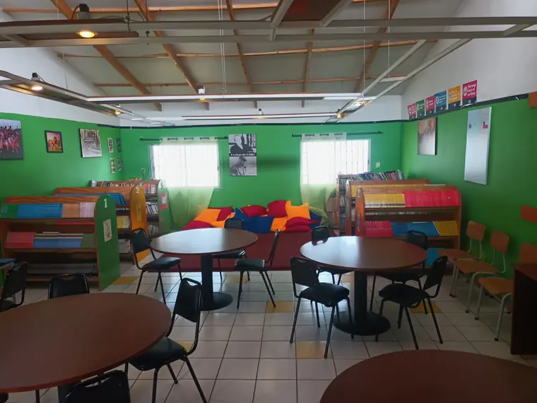

[figure not shown]

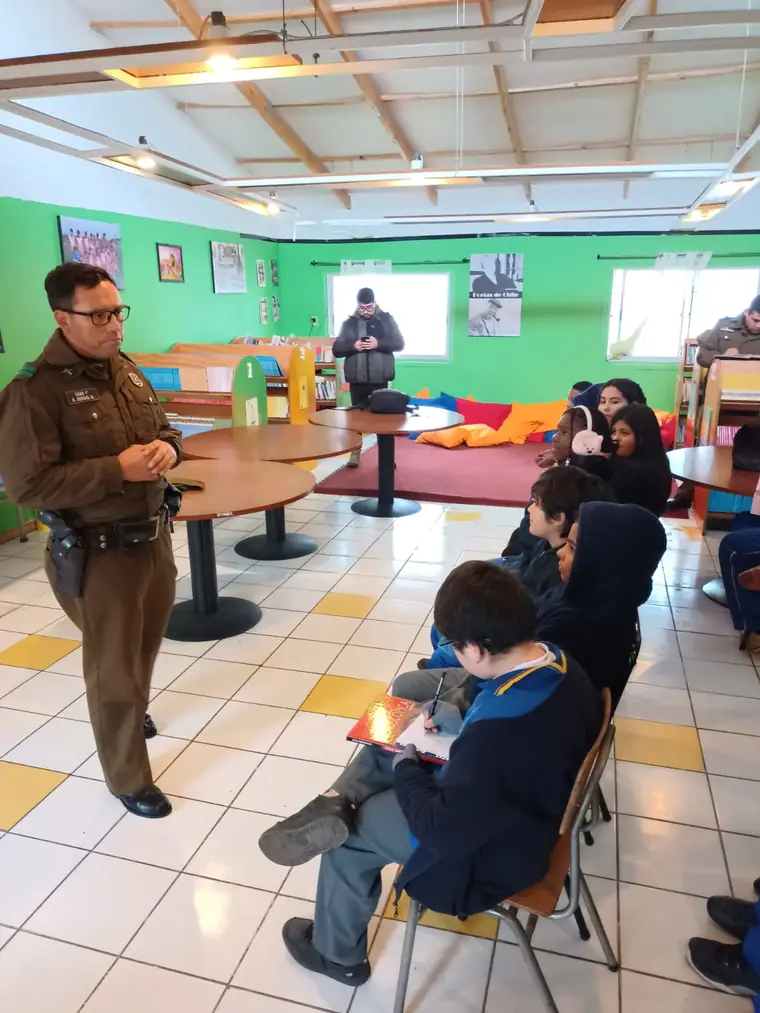

📷Fotografías del establecimiento

Concentración de estudiantes prioritarios

62,3 %

Estudiantes cuya situación socioeconómica puede afectar su rendimiento, según el Ministerio de Educación.

Índice de vulnerabilidad (IVE)

93,8 %

Su comuna: 85,5 %. Lo calcula la JUNAEB y decide a qué establecimientos llegan primero los programas de apoyo.

Cursos en funcionamiento

En enseñanza básica y educación parvularia

Programas y convenios

2

Programa de Integración Escolar · Jornada Escolar Completa

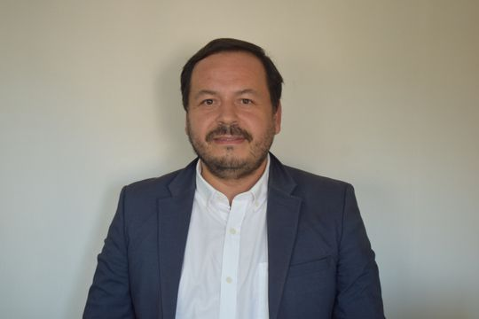

👤Dirección del establecimiento

Daniel Hernández

✉️colegioparquelasamericas@slepsantarosa.cl

📱Celular: +56 9 4718 9013

☎️Teléfono del establecimiento: 3144770

🤝Asesoría técnica del SLEP: Raúl Vasquez Del Pino · raul.vasquez@slepsantarosa.gob.cl

📍Dónde queda

Lo Ovalle 3915, Pedro Aguirre Cerda.

[interactive chart not shown]

Fuente: Coordenadas del directorio consolidado · [Abrir en Google Maps](https://www.google.com/maps/search/?api=1&query=-33.502605,-70.693247)

#### Identificación

**RBD**

9738-1

**Tipo de establecimiento**

Escuela Básica

**Dependencia**

Servicio Local de Educación Pública Santa Rosa

**Estado**

Funcionando

**Comuna**

Pedro Aguirre Cerda

#### Cómo contactarlo

**Dirección**

Lo Ovalle 3915

**Teléfono**

3144770

**Correo**

colegioparquelasamericas@slepsantarosa.cl

#### Equipo y apoyo técnico

**Dirección**

Daniel Hernández

**Unidad Técnico Pedagógica**

utp.colegioparquelasamericas@slepsantarosa.cl

**Inspectoría**

inspectoria.colegioparquelasamericas@slepsantarosa.cl

**Asesoría técnica del SLEP**

Raúl Vasquez Del Pino

**Correo de la asesoría**

raul.vasquez@slepsantarosa.gob.cl

#### Programas y convenios vigentes

Programa de Integración Escolar (PIE)Jornada Escolar CompletaSin PACE

#### Apoyos profesionales al aprendizaje

ReforzamientoPsicopedagogíaPsicologíaProfesor o profesora de educación especialTrabajo socialFonoaudiologíaOrientaciónOrientación vocacional

#### Necesidades educativas que atiende

Tipos de necesidades educativas especiales que el establecimiento declara atender.

Discapacidad intelectualTrastorno del espectro autistaDificultades de aprendizajeTrastorno específico del lenguajeDéficit atencionalFuncionamiento intelectual limítrofe

#### Infraestructura declarada

Biblioteca (CRA)Computación con internetSala audiovisualCancha deportivaAccesibilidad para NEELaboratorio de cienciasSala de usos múltiplesGimnasio techado

#### Documentos públicos

[Proyecto Educativo Institucional (PEI)](https://wwwfs.mineduc.cl/Archivos/infoescuelas/documentos/9738/ProyectoEducativo9738.pdf)[Reglamento de convivencia](https://wwwfs.mineduc.cl/Archivos/infoescuelas/documentos/9738/ReglamentodeConvivencia9738.pdf)[Reglamento de evaluación](https://wwwfs.mineduc.cl/Archivos/infoescuelas/documentos/9738/ReglamentoDeEvaluacion9738.pdf)

**¿Cómo se lee este dato?**

**Qué es**

La identificación oficial del establecimiento y las vías para comunicarse con él.

**De dónde sale**

Del directorio consolidado que el equipo actualiza cada mes con el registro oficial del Ministerio de Educación y los datos del propio Servicio Local.

**Cómo leerlo**

El **RBD** es el número con que el Ministerio identifica a cada establecimiento: sirve para buscarlo en cualquier sistema público. **Dependencia** indica quién lo administra; desde el traspaso, es el Servicio Local de Educación Pública.

**Referencia**

La **concentración de estudiantes prioritarios** es el porcentaje de estudiantes cuya situación socioeconómica puede dificultar su trayectoria escolar; el Ministerio la usa para asignar la subvención escolar preferencial.

**Lo que no dice**

Que un establecimiento tenga más programas no significa mejores resultados: son convenios a los que se postula según su proyecto y su matrícula.

**Para saber más**

[Guía para leer los datos: Cómo leer una ficha (se abre en otra pestaña)](https://datos.slepsantarosa.workers.dev/guia.html#empezar)

El establecimiento · Vida escolar y participación

### 🎭Vida escolar y participación

¿Quiénes participan en la comunidad educativa?

El establecimiento tiene centro de padres y apoderados, con personalidad jurídica vigente.

Centro de padres

Constituido

Personalidad jurídica: vigente

Centro de estudiantes

Sin registro

Puede constituirse en cualquier momento del año

Consejo escolar

Con representante del sostenedor

Bruno Cortés González

#### Centro de padres y apoderados

**Personalidad jurídica**

Vigente

**Certificado de directorio vigente**

DPJ_ESCUELA PARQUE LAS AMÉRICAS.pdf

**Última elección del directorio**

**Próxima elección**

Para contactarlo, escribe al establecimiento: sus datos están en «Identificación y contacto».

#### Centro de estudiantes

El registro del Servicio Local no consigna un centro de estudiantes constituido.

#### Consejo escolar

**Representante del sostenedor**

Bruno Cortés González

**Acompañamiento del SLEP**

Bruno Cortés González

**¿Cómo se lee este dato?**

**Qué es**

Las tres instancias de participación que la ley exige a cada establecimiento: el **consejo escolar** (donde se encuentran dirección, docentes, asistentes, apoderados y estudiantes), el **centro de padres** y el **centro de estudiantes**.

**De dónde sale**

Del registro que mantiene el Servicio Local con los establecimientos, actualizado cuando hay elecciones o cambios de directiva.

**Cómo leerlo**

La **personalidad jurídica** permite al centro de padres administrar recursos propios. Un centro sin directorio vigente no puede firmar convenios ni recibir aportes.

**Lo que no dice**

Que una instancia figure constituida no dice cuán activa es: el registro solo guarda su estado formal.

Capítulo

¿A quiénes educa y cómo avanzan durante el año?

## 🧒Estudiantes

- 🎒Matrícula
- 📅Asistencia
- 🪑Ocupación de cursos
- 🤝Programa de Integración Escolar (PIE)
- 🚶Retiros y traslados

Estudiantes · MatrículaDatos de septiembre de 2026

### 🎒Matrícula

¿Cuántos estudiantes tiene y cómo ha cambiado?

En septiembre de 2026 estudian 169 estudiantes en el establecimiento, 20 menos que en 2025. El 44,4 % son mujeres y el 23,7 % tiene nacionalidad extranjera.

Estudiantes matriculados

169

−20 estudiantes respecto de 2025 (−10,6 %)

82

SLEP 300169

915Rango de los establecimientos del SLEP

Estudiantes por curso

16,9

10 cursos en funcionamiento

10,5

SLEP 23,816,9

39,5Rango de los establecimientos del SLEP

Estudiantes mujeres

44,4 %

75 de 169 estudiantes

0,0 %

SLEP 46,5 %44,4 %

100,0 %Rango de los establecimientos del SLEP

Estudiantes extranjeros

23,7 %

40 de 169 estudiantes

6,5 %

SLEP 29,8 %23,7 %

77,6 %Rango de los establecimientos del SLEP

La matrícula bajó 10,6 % en el último año

Estudiantes matriculados en septiembre de cada año, según el registro mensual del SIGE.

[interactive chart not shown]

Fuente: SIGE, MINEDUC.

#### Género, nacionalidad y origen

Cómo se reparten los 169 estudiantes de septiembre de 2026, según lo que el establecimiento registra de cada uno en el SIGE. Los porcentajes son sobre el total de estudiantes.

#### Por género

- **Mujeres**44,4 % · 75 estudiantes
- **Hombres**55,6 % · 94 estudiantes

#### Por nacionalidad

- **Chilena**76,3 % · 129 estudiantes
- **Extranjera**23,7 % · 40 estudiantes

#### País de origen distinto de Chile

- Haití3,6 %6
- Venezuela3,6 %6
- Otros9,5 %16

Los grupos de menos de 5 estudiantes se suman en «Otros» para no identificar a nadie. Por esa regla no se muestra el desglose por pueblo originario: no quedan al menos dos grupos que se puedan publicar. País de origen: la tarjeta muestra los países declarados en el registro, sin contar Chile (28 estudiantes). Es un dato distinto de la nacionalidad (40 estudiantes de nacionalidad extranjera) y no siempre coincide con ella: muestra lo que el establecimiento registró, no el total de estudiantes de cada país.

**¿Cómo se lee este dato?**

**Qué es**

La cantidad de estudiantes inscritos en el establecimiento en el mes de corte, y cómo se reparte ese total por género, nacionalidad, país de origen y pueblo originario.

**De dónde sale**

Del Sistema de Información General de Estudiantes (SIGE), que cada establecimiento actualiza mes a mes. El género, la nacionalidad, el país de origen y el pueblo originario son los que el establecimiento registra al matricular a cada estudiante.

**Cómo leerlo**

Mira la tendencia de varios años antes que un mes aislado: la matrícula se mueve todo el año por traslados, retiros y nuevas incorporaciones. En el desglose, los grupos de menos de 5 estudiantes se suman en «Otros» para no identificar a nadie; si aun así no quedan al menos dos grupos, ese desglose no se muestra.

**Lo que no dice**

Que un establecimiento tenga más estudiantes no significa que enseñe mejor: el tamaño depende de la infraestructura, de los cupos declarados y del barrio. En el desglose, una diferencia chica entre dos grupos puede ser un solo estudiante: mira también el número, no solo el porcentaje. La nacionalidad y el país de origen son dos datos distintos del registro y no siempre calzan: un estudiante de nacionalidad extranjera puede figurar con Chile como país de origen. Por eso sus cifras no tienen por qué coincidir.

**Para saber más**

[Guía para leer los datos: Matrícula (se abre en otra pestaña)](https://datos.slepsantarosa.workers.dev/guia.html#matricula)

**Ver la matrícula curso por curso (10 cursos)**

Matrícula por curso

| Curso | Estudiantes | % del total |
| --- | --- | --- |
| Pre-kínder A | 19 | 11,2 % |
| Kínder A | 12 | 7,1 % |
| 1° Básico A | 16 | 9,5 % |
| 2° Básico A | 21 | 12,4 % |
| 3° Básico A | 17 | 10,1 % |
| 4° Básico A | 20 | 11,8 % |
| 5° Básico A | 17 | 10,1 % |
| 6° Básico A | 13 | 7,7 % |
| 7° Básico A | 16 | 9,5 % |
| 8° Básico A | 18 | 10,7 % |

Estudiantes · AsistenciaDatos de septiembre de 2026

### 📅Asistencia

¿Cuántos estudiantes van a clases todos los días?

De marzo a septiembre de 2026, los estudiantes asistieron en promedio 82,0 % de los días con clases: 0,8 puntos bajo el promedio del SLEP (82,8 %). Entre las mujeres la asistencia fue de 83,6 % y entre los hombres, de 80,7 %.

Asistencia promedio del año

82,0 %

−3,0 puntos respecto de 2025

49,4 %

SLEP 82,8 %82,0 %

90,4 %Rango de los establecimientos del SLEP

Asistencia de septiembre

84,8 %

169 estudiantes en 10 cursos

Curso con menor asistencia

74,7 %

6° Básico A · 7,3 puntos bajo el promedio del establecimiento

Ningún mes de 2026 alcanza el 85 %

Asistencia promedio del establecimiento en cada mes de 2026, ponderada por la matrícula de cada curso.

[interactive chart not shown]

Fuente: SIGE, MINEDUC.

#### Asistencia por género, nacionalidad y origen

Asistencia promedio de marzo a septiembre de 2026 de cada grupo, calculada igual que la del establecimiento: ponderada por la cantidad de estudiantes del grupo en cada curso. La raya marca el promedio del establecimiento (82,0 %). Bajo el nombre de cada grupo va su cantidad de estudiantes en septiembre.

#### Por género

- Mujeres75 estudiantes83,6 %
- Hombres94 estudiantes80,7 %

Promedio del establecimiento: **82,0 %**

#### Por nacionalidad

- Chilena129 estudiantes80,4 %
- Extranjera40 estudiantes86,8 %

Promedio del establecimiento: **82,0 %**

La asistencia de un grupo se publica solo si tuvo 10 o más estudiantes en todos los meses del período, para no identificar a nadie; los grupos más chicos se suman en «Otros». Por esa regla no se muestra la asistencia por país de origen ni por pueblo originario.

**¿Cómo se lee este dato?**

**Qué es**

La proporción entre los días que un estudiante va a clases y los días que hubo clases. La asistencia de un curso, de un grupo de estudiantes o de un establecimiento es el promedio de esos porcentajes.

**De dónde sale**

El establecimiento registra la asistencia todos los días y la declara cada mes en el Sistema de Información General de Estudiantes (SIGE). Esa misma asistencia es la base de la subvención.

**Cómo leerlo**

Compara cada mes con el mismo mes del año anterior: marzo y diciembre se leen distinto por el ingreso escalonado y el cierre del año. En el desglose por género, nacionalidad y origen, la asistencia de un grupo se publica solo si tuvo 10 o más estudiantes durante todo el período, para no identificar a nadie.

**Referencia**

El Decreto 67 de 2018 exige al menos 85 % de asistencia en el año para ser promovido, con excepciones que autoriza la dirección. El Centro de Estudios del Ministerio usa cuatro categorías: destacada (97 % o más), normal (90 a 97 %), inasistencia reiterada (85 a 90 %) e inasistencia grave (85 % o menos).

**Lo que no dice**

Cuántos estudiantes faltan mucho. Un promedio alto puede esconder a varios estudiantes bajo el 85 %: para saberlo hay que mirar caso a caso, no el promedio. Tampoco que un grupo falte más que otro por una diferencia de uno o dos puntos: en grupos de menos de 20 estudiantes el promedio cambia mucho con un solo caso, y el dato no dice por qué falta cada estudiante.

**Para saber más**

[Guía para leer los datos: Asistencia (se abre en otra pestaña)](https://datos.slepsantarosa.workers.dev/guia.html#asistencia)

**Ver la asistencia curso por curso (10 cursos)**

Asistencia por curso, marzo a septiembre de 2026

| Curso | Estudiantes | Asistencia del año | Situación |
| --- | --- | --- | --- |
| Pre-kínder A | 19 | 74,8 % | Bajo el umbral |
| Kínder A | 13 | 78,5 % | Bajo el umbral |
| 1° Básico A | 14 | 81,6 % | Bajo el umbral |
| 2° Básico A | 21 | 86,5 % | Sobre el umbral |
| 3° Básico A | 18 | 85,3 % | Sobre el umbral |
| 4° Básico A | 21 | 78,9 % | Bajo el umbral |
| 5° Básico A | 18 | 85,6 % | Sobre el umbral |
| 6° Básico A | 11 | 74,7 % | Bajo el umbral |
| 7° Básico A | 18 | 85,8 % | Sobre el umbral |
| 8° Básico A | 19 | 84,0 % | Bajo el umbral |

Estudiantes · Ocupación de cursosDatos de septiembre de 2026

### 🪑Ocupación de cursos

¿Cuántos cupos están ocupados en cada curso?

En septiembre de 2026, 169 estudiantes ocupan los 440 cupos que el establecimiento declaró al Sistema de Admisión Escolar (SAE): 38,4 % de ocupación, con 271 cupos disponibles.

Ocupación de los cupos declarados

38,4 %

169 estudiantes en 440 cupos

33,3 %

SLEP 68,3 %38,4 %

111,2 %Rango de los establecimientos del SLEP

Cursos sobre su capacidad declarada

0

de 10 cursos con cupos declarados

Cupos disponibles

271

repartidos en 10 cursos

Quedan 271 cupos disponibles, repartidos en 10 cursos

Estudiantes matriculados en septiembre de 2026 (barra azul) sobre los cupos que el establecimiento declaró al SAE (barra gris).

[interactive chart not shown]

Fuente: SIGE y Sistema de Admisión Escolar, MINEDUC.

**¿Cómo se lee este dato?**

**Qué es**

La ocupación compara los estudiantes efectivamente matriculados en cada curso con los cupos que el establecimiento declaró al Sistema de Admisión Escolar (SAE).

**De dónde sale**

Los cupos los declara el propio establecimiento en el proceso del SAE; la matrícula sale del registro mensual del SIGE. Las dos cifras viajan en la misma tabla, curso por curso.

**Cómo leerlo**

El 100 % significa que todos los cupos declarados están tomados. Pasar del 100 % quiere decir que hay más estudiantes que cupos: casi siempre es señal de que la capacidad declarada al SAE quedó desactualizada, no de que sobren estudiantes en la sala.

**Referencia**

No hay un umbral oficial: la referencia es la capacidad declarada (100 %). Entre los 53 establecimientos del SLEP que declaran cupos, la ocupación va de 33,3 % a 111,2 %, con un promedio de 68,3 %.

**Lo que no dice**

Cuánto espacio físico real tiene el establecimiento. Un curso puede aparecer con cupos libres porque se reservaron vacantes para el SAE o porque la capacidad declarada es mayor que la que se usa.

**Para saber más**

[Guía para leer los datos: Matrícula (se abre en otra pestaña)](https://datos.slepsantarosa.workers.dev/guia.html#matricula)

**Ver los cupos curso por curso (10 cursos)**

Cupos declarados y matrícula por curso, septiembre de 2026

| Curso | Estudiantes | Cupos declarados | Ocupación | Cupos disponibles |
| --- | --- | --- | --- | --- |
| Pre-kínder A | 19 | 40 | 47,5 % | 21 |
| Kínder A | 12 | 40 | 30,0 % | 28 |
| 1° Básico A | 16 | 45 | 35,6 % | 29 |
| 2° Básico A | 21 | 45 | 46,7 % | 24 |
| 3° Básico A | 17 | 45 | 37,8 % | 28 |
| 4° Básico A | 20 | 45 | 44,4 % | 25 |
| 5° Básico A | 17 | 45 | 37,8 % | 28 |
| 6° Básico A | 13 | 45 | 28,9 % | 32 |
| 7° Básico A | 16 | 45 | 35,6 % | 29 |
| 8° Básico A | 18 | 45 | 40,0 % | 27 |

Estudiantes · PIEDatos de abril de 2026

### 🤝Programa de Integración Escolar (PIE)

¿Cuántos estudiantes reciben apoyos del Programa de Integración Escolar?

45 estudiantes reciben apoyos del Programa de Integración Escolar: 26,6 % de la matrícula, 7,8 puntos sobre el promedio del SLEP (18,8 %).

Estudiantes en el PIE

45

de 169 estudiantes matriculados en septiembre de 2026

3

SLEP 5345

140Rango de los establecimientos del SLEP

Porcentaje de la matrícula

26,6 %

+7,8 puntos respecto del promedio del SLEP (18,8 %)

1,7 %

SLEP 18,8 %26,6 %

34,2 %Rango de los establecimientos del SLEP

Diagnóstico más frecuente

18estudiantes

Lenguaje (TEL) · 40 % de quienes están en el PIE

La cobertura del PIE se ha mantenido estable desde 2024

Estudiantes con necesidades educativas especiales registrados cada año por el Área de Inclusión Educativa del SLEP. Es un catastro distinto de la nómina del SIGE que alimenta las cifras clave, por eso los totales no coinciden exactamente.

[interactive chart not shown]

Fuente: PIE Territorial, Área de Inclusión Educativa del SLEP Santa Rosa.

#### Quiénes reciben los apoyos

Los 45 estudiantes del programa en abril de 2026, según la nómina del SIGE. Cada tarjeta mira una sola característica.

#### Por tipo de necesidad

- **Necesidad permanente**22,2 % · 10 estudiantes
- **Necesidad transitoria**77,8 % · 35 estudiantes

#### Por género

- **Mujeres**33,3 % · 15 estudiantes
- **Hombres**66,7 % · 30 estudiantes

#### Por nivel de enseñanza

- Educación parvularia11 %5
- Educación básica89 %40

#### Por nacionalidad

- **Chilena**82,2 % · 37 estudiantes
- **Extranjera**17,8 % · 8 estudiantes

**¿Cómo se lee este dato?**

**Qué es**

El Programa de Integración Escolar (PIE) entrega apoyos adicionales —profesionales de apoyo, horas de trabajo conjunto con los docentes y materiales— a los estudiantes que tienen una necesidad educativa especial (NEE) diagnosticada, dentro de la misma sala de clases.

**De dónde sale**

El detalle por estudiante sale de la nómina PIE del SIGE (abril de 2026) y la serie por año, del catastro del Área de Inclusión Educativa del SLEP. Son dos registros distintos, con fechas distintas: sus totales no calzan exactamente.

**Cómo leerlo**

Una necesidad «permanente» acompaña a la persona durante toda su vida —por ejemplo una discapacidad intelectual, sensorial o motora— y da derecho a apoyos en toda la trayectoria escolar. Una necesidad «transitoria» se presenta en un período de la escolaridad y se espera que se supere con apoyo, como las dificultades del aprendizaje o del lenguaje. En la mayoría de los establecimientos las transitorias son las más numerosas.

**Referencia**

En el SLEP Santa Rosa el promedio es 18,8 % de la matrícula. El programa se rige por el Decreto 170 del Ministerio de Educación, que define qué diagnósticos puede atender y qué apoyos financia.

**Lo que no dice**

Un porcentaje alto de estudiantes en el PIE no es un mal resultado: habla de cuántos estudiantes tienen apoyos reconocidos y financiados, no de cómo enseña el establecimiento. Tampoco dice cuántos estudiantes necesitan apoyo, porque solo cuenta a quienes ya tienen un diagnóstico vigente y entraron al programa. Por lo mismo, las diferencias por género, nivel o nacionalidad muestran a quiénes se ha diagnosticado, no quiénes necesitan más apoyo. Los grupos de menos de 5 estudiantes se suman en «Otros» para no identificar a nadie, y con menos de 5 estudiantes en el programa no se muestra ningún desglose.

**Ver el detalle por diagnóstico**

Estudiantes del PIE por diagnóstico

| Diagnóstico | Tipo de necesidad | Estudiantes | % del PIE |
| --- | --- | --- | --- |
| Lenguaje (TEL) | Transitoria | 18 | 40,0 % |
| Otros diagnósticos transitorios | Transitoria | 17 | 37,8 % |
| Necesidades permanentes, sin detalle | Permanente | 10 | 22,2 % |

Estudiantes · Retiros y trasladosDatos de septiembre de 2026

### 🚶Retiros y traslados

¿Cuántos estudiantes se fueron durante el año y por qué?

En 2026 se registraron 28 retiros: 16,6 % de la matrícula, 2,8 puntos sobre el promedio del SLEP (13,7 %).

Retiros registrados en 2026

28

+2 respecto del mismo período de 2025 (26 retiros)

1

SLEP 3928

155Rango de los establecimientos del SLEP

Porcentaje de la matrícula

16,6 %

+2,8 puntos respecto del promedio del SLEP (13,7 %)

0,6 %

SLEP 13,7 %16,6 %

103,3 %Rango de los establecimientos del SLEP

Dejaron el establecimiento

28estudiantes

23 siguieron en otro establecimiento y 5 quedaron sin matrícula posterior

Agosto concentró la mayor cantidad de retiros: 8 de 28

Retiros registrados cada mes de 2026, desde marzo hasta septiembre.

[interactive chart not shown]

Fuente: Registro de retiros y traslados del SIGE, MINEDUC.

#### Quiénes dejaron el establecimiento

28 estudiantes dejaron el establecimiento en 2026. No se cuentan los cambios de curso internos y cada estudiante aparece una vez, por su último movimiento del año. La comuna de destino se conoce para los 23 que se matricularon en otro establecimiento.

#### Por género

- **Mujeres**46,4 % · 13 estudiantes
- **Hombres**53,6 % · 15 estudiantes

#### Por nacionalidad

- **Chilena**64,3 % · 18 estudiantes
- **Extranjera**35,7 % · 10 estudiantes

#### Por curso

- 2° Básico18 %5
- Otros cursos82 %23

#### Por comuna de destino

- Lo Espejo39 %9
- Otras comunas61 %14

Los grupos de menos de 5 estudiantes se suman en «Otros» para no identificar a nadie.

**¿Cómo se lee este dato?**

**Qué es**

Un retiro es el registro que hace el establecimiento en el SIGE cuando un estudiante deja su curso durante el año escolar. No todos los retiros son iguales: la mayoría son traslados, es decir, el estudiante se matricula en otro establecimiento y sigue estudiando.

**De dónde sale**

Del registro de retiros y traslados del SIGE, cruzado con la matrícula vigente para saber dónde quedó cada estudiante. El corte de estos datos es septiembre de 2026.

**Cómo leerlo**

Distingue el «traslado a otro establecimiento» —el estudiante sigue en el sistema escolar, dentro o fuera del SLEP— del «retiro sin matrícula posterior», que es el que conviene mirar de cerca, porque puede anticipar una desvinculación del sistema. Los meses de marzo y diciembre concentran movimientos administrativos —regularizaciones de inicio de año y cierres de curso—, así que un alza en esos meses no significa lo mismo que un alza en mitad del año. Los desgloses por género, nacionalidad, nivel y destino cuentan estudiantes, no movimientos, y dejan fuera los cambios de curso internos.

**Referencia**

En el SLEP Santa Rosa los retiros equivalen en promedio a 13,7 % de la matrícula en lo que va de 2026. La comparación se hace con el mismo corte para todos los establecimientos.

**Lo que no dice**

El retiro no es lo mismo que la deserción: solo la matrícula del año siguiente confirma si un estudiante dejó de estudiar. Y como el año todavía no termina, la cifra seguirá subiendo hasta diciembre: no se puede comparar con el total de un año cerrado. Los desgloses tampoco dicen por qué se fue cada estudiante, y con tan pocos casos una diferencia entre grupos puede ser casualidad. Los grupos de menos de 5 estudiantes se suman en «Otros» para no identificar a nadie.

**Para saber más**

[Guía para leer los datos: Matrícula (se abre en otra pestaña)](https://datos.slepsantarosa.workers.dev/guia.html#matricula)

**Ver el detalle mes a mes**

Retiros de 2026 por mes

| Mes del retiro | Retiros |
| --- | --- |
| Marzo | 2 |
| Abril | 6 |
| Mayo | 3 |
| Junio | 0 |
| Julio | 3 |
| Agosto | 8 |
| Septiembre | 6 |
| Total | 28 |

Capítulo

¿Qué están aprendiendo sus estudiantes?

## 📚Aprendizajes

- 📗Rendimiento
- 📊SIMCE
- 🏷️Categoría de desempeño
- 💛Desarrollo personal y social
- 🧭Diagnóstico Integral de Aprendizajes (DIA)

Aprendizajes · RendimientoDatos de año escolar 2025

### 📗Rendimiento

¿Cuántos estudiantes aprobaron el año?

En 2025, 100,0 % de los estudiantes que terminaron el año fue promovido de curso, 3,5 puntos sobre el promedio del SLEP.

Estudiantes promovidos

100,0 %

0,0 puntos respecto de 2024

49,7 %

SLEP 96,5 %100,0 %

100,0 %Rango de los establecimientos del SLEP

Nota promedio del establecimiento

6,1

Promedio general de 161 estudiantes con nota final

5,4

SLEP 5,96,1

6,3Rango de los establecimientos del SLEP

Reprobados por inasistencia

0

De 0 estudiantes reprobados en 2025

La aprobación se mantiene estable

Porcentaje de estudiantes promovidos sobre los que terminaron el año en el establecimiento (no incluye retirados ni trasladados).

Promedio del SLEP en 2025: 96,5 %

[interactive chart not shown]

Fuente: Actas de rendimiento, SIGE.

#### Aprobación y notas por género y nacionalidad

Resultados de 2025 de quienes terminaron el año, mirando una característica a la vez. La raya marca el valor de todo el establecimiento.

#### Aprobación por género

- Mujeres72 estudiantes100,0 %
- Hombres89 estudiantes100,0 %

Aprobación del establecimiento: **100,0 %**

#### Nota promedio por género

- Mujeres72 con nota final6,2
- Hombres89 con nota final5,9

Nota del establecimiento: **6,1**

#### Aprobación por nacionalidad

- Chilena117 estudiantes100,0 %
- Extranjera44 estudiantes100,0 %

Aprobación del establecimiento: **100,0 %**

#### Nota promedio por nacionalidad

- Chilena117 con nota final6,1
- Extranjera44 con nota final6,1

Nota del establecimiento: **6,1**

**¿Cómo se lee este dato?**

**Qué es**

El resultado del año escolar de cada estudiante: promovido al curso siguiente o reprobado.

**De dónde sale**

De las actas de rendimiento que el establecimiento entrega al Ministerio al cerrar el año, a través del SIGE.

**Cómo leerlo**

La aprobación se calcula sobre quienes **terminaron el año** en el establecimiento. Los estudiantes **retirados** o **trasladados** se cuentan aparte (sección Retiros y traslados), porque su resultado final lo registra otro establecimiento. La nota promedio es el promedio general de cada estudiante con nota final, no un promedio de cursos.

**Referencia**

Un estudiante puede reprobar por notas o por asistencia inferior al 85 % sin justificación aceptada por la dirección.

**Lo que no dice**

Una aprobación de 100 % no significa por sí sola que todos aprendieron lo esperado: para eso están los resultados del SIMCE y del DIA. Las diferencias por género, nacionalidad o curso tampoco explican su causa, y en grupos chicos un solo estudiante mueve varios puntos: por eso las tasas y los promedios solo se muestran para grupos de 10 o más estudiantes, y los más chicos se suman en «Otros» para no identificar a nadie.

**Para saber más**

[Guía para leer los datos: Rendimiento (se abre en otra pestaña)](https://datos.slepsantarosa.workers.dev/guia.html#rendimiento)

**Ver el detalle por curso**

Rendimiento por curso

| Curso | Evaluados | Aprobación | Nota promedio |
| --- | --- | --- | --- |
| 1° Básico | 23 | 100,0 % | 6,5 |
| 2° Básico | 21 | 100,0 % | 6,4 |
| 3° Básico | 23 | 100,0 % | 6,1 |
| 4° Básico | 21 | 100,0 % | 6,0 |
| 5° Básico | 14 | 100,0 % | 6,0 |
| 6° Básico | 19 | 100,0 % | 5,7 |
| 7° Básico | 21 | 100,0 % | 6,0 |
| 8° Básico | 19 | 100,0 % | 5,7 |

Aprendizajes · SIMCEDatos de 2025

### 📊SIMCE

¿Cómo les fue en las pruebas nacionales SIMCE?

En 2025, 4° básico obtuvo 248 pts en Lectura, 10 puntos por debajo de el promedio del SLEP.

Lectura · 4° básico

248 pts

+8 pts respecto de 2024

200

SLEP 258248

314Rango de los establecimientos del SLEP

Matemática · 4° básico

223 pts

+1 pts respecto de 2024

199

SLEP 241223

290Rango de los establecimientos del SLEP

Lectura · 8° básico

194 pts

+4 pts respecto de 2019

175

SLEP 217194

258Rango de los establecimientos del SLEP

Evolución de los puntajes en 4° básico

Puntaje promedio del establecimiento en cada aplicación del SIMCE. No hubo SIMCE en 2020 ni 2021.

[interactive chart not shown]

Fuente: Agencia de Calidad de la Educación.

Para 2025 la Agencia de Calidad publicó los puntajes pero no cuántos estudiantes rindieron la prueba en este establecimiento. Por eso los promedios del SLEP de ese año son simples, no ponderados por matrícula evaluada.

**¿Cómo se lee este dato?**

**Qué es**

El SIMCE es la prueba nacional que aplica la Agencia de Calidad para saber qué aprendieron los estudiantes en Lectura, Matemática y, en algunos años, Ciencias.

**De dónde sale**

De los resultados oficiales que publica la Agencia de Calidad de la Educación por establecimiento y grado.

**Cómo leerlo**

Un puntaje aislado dice poco: compáralo con el promedio del SLEP (la barra de cada tarjeta) y con los años anteriores del mismo curso. Los estándares —**Insuficiente**, **Elemental** y **Adecuado**— dicen cuántos estudiantes alcanzaron lo esperado, que suele ser más informativo que el promedio.

**Referencia**

Diferencias menores a 5 puntos entre años no son significativas: dependen de qué estudiantes rindieron la prueba ese año.

**Lo que no dice**

El SIMCE no mide todo lo que hace una escuela: no evalúa artes, deportes, convivencia ni el progreso individual de cada estudiante.

**Para saber más**

[Guía para leer los datos: SIMCE (se abre en otra pestaña)](https://datos.slepsantarosa.workers.dev/guia.html#simce)

**Ver todos los resultados**

Resultados SIMCE por año, curso y asignatura

| Año | Curso | Asignatura | Puntaje | Evaluados |
| --- | --- | --- | --- | --- |
| 2025 | 4° básico | Lectura | 248 | sin dato |
| 2025 | 4° básico | Matemática | 223 | sin dato |
| 2025 | 8° básico | Lectura | 194 | sin dato |
| 2025 | 8° básico | Matemática | 230 | sin dato |
| 2024 | 4° básico | Lectura | 240 | 16 |
| 2024 | 4° básico | Matemática | 222 | 16 |
| 2024 | 6° básico | Lectura | 225 | 23 |
| 2024 | 6° básico | Matemática | 211 | 23 |
| 2023 | 4° básico | Lectura | 249 | 13 |
| 2023 | 4° básico | Matemática | 244 | 14 |
| 2022 | 4° básico | Lectura | 243 | 20 |
| 2022 | 4° básico | Matemática | 229 | 20 |
| 2019 | 8° básico | Historia y Ciencias Sociales | 213 | 28 |
| 2019 | 8° básico | Lectura | 190 | 26 |
| 2019 | 8° básico | Matemática | 212 | 23 |
| 2018 | 4° básico | Lectura | 208 | 25 |
| 2018 | 4° básico | Matemática | 207 | 27 |
| 2018 | 6° básico | Ciencias Naturales | 204 | 26 |
| 2018 | 6° básico | Lectura | 203 | 25 |
| 2018 | 6° básico | Matemática | 203 | 27 |
| 2017 | 4° básico | Lectura | 243 | 37 |
| 2017 | 4° básico | Matemática | 226 | 39 |
| 2016 | 4° básico | Lectura | 210 | 29 |
| 2016 | 4° básico | Matemática | 232 | 27 |
| 2016 | 6° básico | Historia y Ciencias Sociales | 224 | 39 |
| 2016 | 6° básico | Lectura | 227 | 39 |
| 2016 | 6° básico | Matemática | 220 | 36 |

Aprendizajes · Categoría de desempeñoDatos de 2019

### 🏷️Categoría de desempeño

¿Cómo clasifica la Agencia de Calidad a este establecimiento?

En 2019 la Agencia de Calidad clasificó al establecimiento como Insuficiente en educación básica.

La Agencia de Calidad ordena a todos los establecimientos del país en cuatro categorías. No mira solo el SIMCE: combina los puntajes con los indicadores de desarrollo personal y social, con el contexto socioeconómico de los estudiantes y con cuánto avanzó el establecimiento respecto de sí mismo. La categoría define qué apoyo recibe del Estado.

Educación básica

Insuficiente

En 2018 era medio-bajo.

Cómo ha cambiado la clasificación

Categoría asignada en cada año con clasificación publicada. El color del punto repite la categoría: verde Alto, azul Medio, amarillo Medio-bajo, rojo Insuficiente.

[interactive chart not shown]

Fuente: Agencia de Calidad de la Educación.

#### El historial completo

Categoría de desempeño por año y nivel

| Año | Nivel | Categoría |
| --- | --- | --- |
| 2019 | Básica | Insuficiente |
| 2018 | Básica | Medio-bajo |
| 2017 | Básica | Insuficiente |
| 2016 | Básica | Insuficiente |

La última clasificación en las bases del equipo es de 2019. Mientras la Agencia no publique una nueva, esa sigue siendo la categoría vigente del establecimiento.

**¿Cómo se lee este dato?**

**Qué es**

La clasificación oficial que la Agencia de Calidad hace de cada establecimiento del país, una vez al año.

**De dónde sale**

De las ordenaciones que publica la Agencia de Calidad de la Educación, por establecimiento y nivel de enseñanza.

**Cómo leerlo**

Las cuatro categorías, de mayor a menor, son **Alto**, **Medio**, **Medio-bajo** e **Insuficiente**. Se comparan establecimientos de contexto socioeconómico parecido, así que la categoría no es lo mismo que el puntaje SIMCE: una escuela puede tener puntajes bajos y aun así quedar en Medio si avanza más que las escuelas con las que se la compara.

**Referencia**

Las categorías **Medio-bajo** e **Insuficiente** obligan a la Agencia a acompañar al establecimiento con apoyo técnico. Mantenerse en Insuficiente durante cuatro años seguidos puede terminar en la pérdida del reconocimiento oficial.

**Lo que no dice**

La categoría no mide el trabajo de un profesor ni de un curso: es del establecimiento completo y se calcula con datos de varios años, así que refleja una trayectoria, no el año en curso.

**Para saber más**

[Guía para leer los datos: Categoría de Desempeño (se abre en otra pestaña)](https://datos.slepsantarosa.workers.dev/guia.html#categoria-desempeno)

Aprendizajes · Desarrollo personal y socialDatos de 2025

### 💛Desarrollo personal y social

¿Cómo se sienten los estudiantes en su establecimiento?

Entre 2016 y 2025 la Agencia midió estos indicadores 8 veces. El mayor cambio de la última fue autoestima académica y motivación escolar, que subió 9,5 puntos respecto de 2024 (de 69,0 a 78,5 de 100).

Autoestima académica y motivación escolar

78,5de 100

9,5 puntos más que en 2024

Sobre el contexto similar

Clima de convivencia escolar

79,0de 100

6,0 puntos más que en 2024

Sobre el contexto similar

Participación y formación ciudadana

81,0de 100

5,0 puntos más que en 2024

Sobre el contexto similar

Hábitos de vida saludable

72,0de 100

5,0 puntos más que en 2024

Igual que el contexto similar

Cómo cambió cada indicador entre 2016 y 2025

Puntaje promedio del establecimiento en cada aplicación, de 0 a 100. Años con datos: 2016, 2017, 2018, 2019, 2022, 2023, 2024 y 2025. No hubo medición en 2020 y 2021. El eje vertical va de 55 a 90 puntos, no parte en cero, para que se vea el movimiento.

[interactive chart not shown]

Fuente: Agencia de Calidad de la Educación · cuestionarios SIMCE.

En 2025, lo más alto fue participación y formación ciudadana y lo más bajo, hábitos de vida saludable

Puntaje de 0 a 100. La barra azul es el establecimiento; la gris, el promedio de los establecimientos de contexto socioeconómico similar que usa la Agencia para comparar. En 2025 quedó sobre ese promedio en 3 de los 4 indicadores y igual en 1.

[interactive chart not shown]

Fuente: Agencia de Calidad de la Educación · cuestionarios SIMCE.

**¿Cómo se lee este dato?**

**Qué es**

Cuatro indicadores que miden cómo viven los estudiantes su escuela: autoestima académica y motivación, clima de convivencia, participación y formación ciudadana, y hábitos de vida saludable.

**De dónde sale**

De los cuestionarios que responden estudiantes, familias y docentes junto con el SIMCE. Los calcula la Agencia de Calidad.

**Cómo leerlo**

Van de 0 a 100 y no son notas: 100 sería que todas las respuestas apuntan en la dirección deseada. En el gráfico de evolución, cada línea es un indicador y su color lo identifica; el eje vertical está recortado al rango de los datos para que el movimiento se vea, y se corta en los años sin aplicación. En el gráfico del último año el color dice quién es, no si el resultado es bueno: azul el establecimiento, gris el promedio de establecimientos de contexto socioeconómico similar; la etiqueta de cada tarjeta dice con palabras si el establecimiento quedó sobre, bajo o igual que ese promedio, y una diferencia menor a medio punto se lee como «igual». En 2025 se evaluó más de un curso, así que el puntaje es el promedio de esos cursos y por eso lleva un decimal.

**Referencia**

Estos indicadores pesan un tercio de la Categoría de Desempeño que asigna la Agencia de Calidad. La comparación con establecimientos de contexto similar viene en las bases de 2024 y 2025.

**Lo que no dice**

No miden la convivencia del año en curso: reflejan lo que respondieron las personas el año de la evaluación. Tampoco son un seguimiento de los mismos estudiantes: cada aplicación mide a los cursos que rindieron el SIMCE ese año, que no siempre son los mismos, así que parte del cambio entre años viene de qué cursos se evaluaron.

**Para saber más**

[Guía para leer los datos: Categoría de Desempeño (se abre en otra pestaña)](https://datos.slepsantarosa.workers.dev/guia.html#categoria-desempeno)

**Ver el detalle por año y curso**

Indicadores de desarrollo personal y social

| Año | Curso | Indicador | Puntaje | Contexto similar | Diferencia |
| --- | --- | --- | --- | --- | --- |
| 2025 | 4b | Autoestima académica y motivación escolar | 75,0 | 76,0 | −1 |
| 2025 | 8b | Autoestima académica y motivación escolar | 82,0 | 76,0 | +6 |
| 2025 | 4b | Clima de convivencia escolar | 79,0 | 76,0 | +3 |
| 2025 | 4b | Participación y formación ciudadana | 78,0 | 79,0 | −1 |
| 2025 | 8b | Participación y formación ciudadana | 84,0 | 79,0 | +5 |
| 2025 | 4b | Hábitos de vida saludable | 68,0 | 71,0 | −3 |
| 2025 | 8b | Hábitos de vida saludable | 76,0 | 73,0 | +3 |
| 2024 | 4b | Autoestima académica y motivación escolar | 69,0 | 76,0 | −7 |
| 2024 | 4b | Clima de convivencia escolar | 73,0 | 75,0 | −2 |
| 2024 | 4b | Participación y formación ciudadana | 76,0 | 79,0 | −3 |
| 2024 | 4b | Hábitos de vida saludable | 67,0 | 70,0 | −3 |
| 2023 | 4b | Autoestima académica y motivación escolar | 79,0 | — | — |
| 2023 | 4b | Clima de convivencia escolar | 85,0 | — | — |
| 2023 | 4b | Participación y formación ciudadana | 86,0 | — | — |
| 2023 | 4b | Hábitos de vida saludable | 76,0 | — | — |
| 2022 | 4b | Autoestima académica y motivación escolar | 79,0 | — | — |
| 2022 | 4b | Clima de convivencia escolar | 79,0 | — | — |
| 2022 | 4b | Participación y formación ciudadana | 81,0 | — | — |
| 2022 | 4b | Hábitos de vida saludable | 74,0 | — | — |
| 2019 | 8b | Autoestima académica y motivación escolar | 78,1 | — | — |
| 2019 | 8b | Clima de convivencia escolar | 76,2 | — | — |
| 2019 | 8b | Participación y formación ciudadana | 76,8 | — | — |
| 2019 | 8b | Hábitos de vida saludable | 66,9 | — | — |
| 2018 | 4b | Autoestima académica y motivación escolar | 64,9 | — | — |
| 2018 | 6b | Autoestima académica y motivación escolar | 70,0 | — | — |
| 2018 | 4b | Clima de convivencia escolar | 62,4 | — | — |
| 2018 | 6b | Clima de convivencia escolar | 62,2 | — | — |
| 2018 | 4b | Participación y formación ciudadana | 70,7 | — | — |
| 2018 | 6b | Participación y formación ciudadana | 69,2 | — | — |
| 2018 | 4b | Hábitos de vida saludable | 57,7 | — | — |
| 2018 | 6b | Hábitos de vida saludable | 65,2 | — | — |
| 2017 | 4b | Autoestima académica y motivación escolar | 73,5 | — | — |
| 2017 | 8b | Autoestima académica y motivación escolar | 75,9 | — | — |
| 2017 | 4b | Clima de convivencia escolar | 72,6 | — | — |
| 2017 | 8b | Clima de convivencia escolar | 69,4 | — | — |
| 2017 | 4b | Participación y formación ciudadana | 74,7 | — | — |
| 2017 | 8b | Participación y formación ciudadana | 76,2 | — | — |
| 2017 | 4b | Hábitos de vida saludable | 56,8 | — | — |
| 2017 | 8b | Hábitos de vida saludable | 63,6 | — | — |
| 2016 | 4b | Autoestima académica y motivación escolar | 79,0 | — | — |
| 2016 | 6b | Autoestima académica y motivación escolar | 74,0 | — | — |
| 2016 | 4b | Clima de convivencia escolar | 65,0 | — | — |
| 2016 | 6b | Clima de convivencia escolar | 74,0 | — | — |
| 2016 | 4b | Participación y formación ciudadana | 80,0 | — | — |
| 2016 | 6b | Participación y formación ciudadana | 82,0 | — | — |
| 2016 | 4b | Hábitos de vida saludable | 71,0 | — | — |
| 2016 | 6b | Hábitos de vida saludable | 72,0 | — | — |

Aprendizajes · Diagnóstico Integral de Aprendizajes (DIA)Datos al 29 sep 2026

### 🧭Diagnóstico Integral de Aprendizajes (DIA)

¿Qué aprendizajes lograron durante el año según el DIA?

En el monitoreo intermedio 2026, la edición más reciente del DIA, 26,2 % de los 122 estudiantes evaluados en Lectura y 39,5 % de los 124 estudiantes evaluados en Matemática quedaron en Nivel I: todavía no alcanzan los aprendizajes mínimos de los objetivos evaluados.

El Diagnóstico Integral de Aprendizajes (DIA) es una evaluación voluntaria y formativa de la Agencia de Calidad de la Educación, que cada establecimiento aplica para uso interno en tres momentos del año: diagnóstico (marzo y abril), monitoreo intermedio (julio y agosto) y cierre (octubre a diciembre). No pone notas, no evalúa a docentes y no ordena establecimientos: sirve para ver cómo van los estudiantes y ajustar la enseñanza durante el año.

Este establecimiento tiene resultados de 8 ediciones y 2 evaluaciones del DIA de Educación Parvularia, entre 2024 y 2026. Cada una usa sus propios instrumentos y responde una pregunta distinta: por eso se muestran de a una.

Lectura: estudiantes en Nivel I

26,2 %

Monitoreo intermedio 2026 · 122 evaluados · en el SLEP, mismos grados: 18,1 %

Lectura: estudiantes en Nivel III

13,1 %

Monitoreo intermedio 2026 · 122 evaluados · en el SLEP, mismos grados: 17,7 %

Matemática: estudiantes en Nivel I

39,5 %

Monitoreo intermedio 2026 · 124 evaluados · en el SLEP, mismos grados: 44,3 %

Matemática: estudiantes en Nivel III

21,8 %

Monitoreo intermedio 2026 · 124 evaluados · en el SLEP, mismos grados: 14,1 %

#### Las ediciones del DIA de este establecimiento

Ediciones del DIA con resultados, por año y momento, y qué se aplicó en cada una

[output not shown]

Cada edición se lee por separado. La Agencia de Calidad indica no comparar un año con otro, ni el diagnóstico con el monitoreo intermedio. Lo único que se compara es el avance dentro de un mismo año, y está en la pestaña de cada cierre.

#### Edición por edición

Estudiantes en Nivel I: el 26,2 % en Lectura y el 39,5 % en Matemática

¿Cómo van los aprendizajes a mitad de año? El monitoreo intermedio, aplicado del 7 de julio al 28 de agosto de 2026 (plazo extendido), mide cómo van los aprendizajes de los objetivos del año en curso. Desde 2026 las pruebas cubren las Bases Curriculares completas, con instrumentos nuevos.

Nivel I · no alcanza los aprendizajes mínimosNivel II · los alcanza parcialmenteNivel III · los alcanza satisfactoriamente

**Lectura · 122 evaluados**

- **Nivel I**26,2 % · 32 estudiantes
- **Nivel II**60,7 % · 74 estudiantes
- **Nivel III**13,1 % · 16 estudiantes

**Matemática · 124 evaluados**

- **Nivel I**39,5 % · 49 estudiantes
- **Nivel II**38,7 % · 48 estudiantes
- **Nivel III**21,8 % · 27 estudiantes

**Historia y Cs. Sociales · 65 evaluados**

- **Nivel I**52,3 % · 34 estudiantes
- **Nivel II**36,9 % · 24 estudiantes
- **Nivel III**10,8 % · 7 estudiantes

**Ciencias Naturales · 52 evaluados**

- **Nivel I**59,6 % · 31 estudiantes
- **Nivel II**38,5 % · 20 estudiantes
- **Nivel III**1,9 % · 1 estudiante

**Contexto del SLEP**

En los mismos grados, quedó en Nivel I el 18,1 % en Lectura, 44,3 % en Matemática, 52,6 % en Historia y Cs. Sociales, 54,9 % en Ciencias Naturales. Es contexto: el DIA no se usa para comparar establecimientos.

**Grupos pequeños**

Ciencias Naturales 6° básico (9): con menos de 10 evaluados se informa la cantidad, no los porcentajes. Tampoco entra en la cifra del establecimiento, para que no se pueda deducir restando.

[interactive chart not shown]

**Ver esta edición en tabla, con los ejes y habilidades (27 filas)**

Niveles de logro del DIA por asignatura y grado, monitoreo intermedio 2026

| Asignatura y grado | Evaluados | Nivel I | Nivel II | Nivel III | Respuestas correctas por eje o habilidad |
| --- | --- | --- | --- | --- | --- |
| Lectura · establecimiento | 122 | 26,2 % | 60,7 % | 13,1 % | — |
| Lectura · 2° básico | 20 | 0,0 % | 80,0 % | 20,0 % | Localizar 70 % · Interpretar y relacionar 70 % · Reflexionar 56 % |
| Lectura · 3° básico | 17 | 5,9 % | 41,2 % | 52,9 % | Localizar 68 % · Interpretar y relacionar 71 % · Reflexionar 54 % |
| Lectura · 4° básico | 21 | 33,3 % | 57,1 % | 9,5 % | Localizar 57 % · Interpretar y relacionar 41 % · Reflexionar 43 % |
| Lectura · 5° básico | 18 | 50,0 % | 50,0 % | 0,0 % | Localizar 44 % · Interpretar y relacionar 40 % · Reflexionar 47 % |
| Lectura · 6° básico | 10 | 40,0 % | 60,0 % | 0,0 % | Localizar 36 % · Interpretar y relacionar 35 % · Reflexionar 29 % |
| Lectura · 7° básico | 17 | 41,2 % | 58,8 % | 0,0 % | Localizar 53 % · Interpretar y relacionar 40 % · Reflexionar 40 % |
| Lectura · 8° básico | 19 | 21,1 % | 73,7 % | 5,3 % | Localizar 49 % · Interpretar y relacionar 59 % · Reflexionar 39 % |
| Matemática · establecimiento | 124 | 39,5 % | 38,7 % | 21,8 % | — |
| Matemática · 1° básico | 16 | — | — | — | Números y operaciones 88 % · Patrones y álgebra 83 % · Geometría 96 % · Medición 62 % · Datos y probabilidades 97 % · Toda la prueba 87 % |
| Matemática · 2° básico | 21 | 0,0 % | 33,3 % | 66,7 % | Números y operaciones 68 % · Patrones y álgebra 93 % · Geometría 98 % · Medición 67 % · Datos y probabilidades 84 % |
| Matemática · 3° básico | 18 | 0,0 % | 61,1 % | 38,9 % | Números y operaciones 67 % · Patrones y álgebra 81 % · Geometría 79 % · Medición 70 % · Datos y probabilidades 61 % |
| Matemática · 4° básico | 20 | 35,0 % | 60,0 % | 5,0 % | Números y operaciones 51 % · Patrones y álgebra 33 % · Geometría 49 % · Medición 45 % · Datos y probabilidades 27 % |
| Matemática · 5° básico | 18 | 88,9 % | 11,1 % | 0,0 % | Números y operaciones 28 % · Patrones y álgebra 15 % · Geometría 49 % · Medición 44 % · Datos y probabilidades 39 % |
| Matemática · 6° básico | 10 | 50,0 % | 50,0 % | 0,0 % | Números y operaciones 33 % · Patrones y álgebra 48 % · Geometría 43 % · Medición 41 % · Datos y probabilidades 49 % |
| Matemática · 7° básico | 18 | 66,7 % | 22,2 % | 11,1 % | Números 25 % · Álgebra y funciones 34 % · Geometría 46 % · Probabilidad y estadística 40 % |
| Matemática · 8° básico | 19 | 47,4 % | 36,8 % | 15,8 % | Números 66 % · Álgebra y funciones 41 % · Geometría 38 % · Probabilidad y estadística 40 % |
| Historia y Cs. Sociales · establecimiento | 65 | 52,3 % | 36,9 % | 10,8 % | — |
| Historia y Cs. Sociales · 5° básico | 18 | 77,8 % | 22,2 % | 0,0 % | Historia 25 % · Geografía 35 % · Formación Ciudadana 31 % |
| Historia y Cs. Sociales · 6° básico | 10 | 50,0 % | 40,0 % | 10,0 % | Historia 52 % · Geografía 41 % · Formación Ciudadana 33 % |
| Historia y Cs. Sociales · 7° básico | 18 | 38,9 % | 50,0 % | 11,1 % | Historia 46 % · Geografía 41 % · Formación Ciudadana 42 % |
| Historia y Cs. Sociales · 8° básico | 19 | 42,1 % | 36,8 % | 21,1 % | Historia 49 % · Geografía 40 % · Formación Ciudadana 58 % |
| Ciencias Naturales · establecimiento | 52 | 59,6 % | 38,5 % | 1,9 % | — |
| Ciencias Naturales · 5° básico | 16 | 56,2 % | 43,8 % | 0,0 % | Ciencias de la vida 46 % · Ciencias Físicas y Químicas 32 % · Ciencias de la Tierra y el Universo 27 % |
| Ciencias Naturales · 6° básico | 9 | — | — | — | — |
| Ciencias Naturales · 7° básico | 17 | 70,6 % | 23,5 % | 5,9 % | Biología 32 % · Física 32 % · Química 42 % |
| Ciencias Naturales · 8° básico | 19 | 52,6 % | 47,4 % | 0,0 % | Biología 52 % · Física 32 % · Química 33 % |

Fuente: Agencia de Calidad de la Educación · plataforma DIA, monitoreo intermedio 2026. [Informe estratégico de esta edición (se abre en otra pestaña)](https://datos.slepsantarosa.workers.dev/visor.html?id=dia-intermedio-2026)

#### 1.° básico: lo que no se informa con niveles de logro

Lectura en 1.° básico · tareas logradas

16 estudiantes. En 1.° básico la prueba no entrega nivel de logro: informa qué porcentaje del curso logra cada tarea de la lectura inicial.

- Sílaba inicialConciencia fonológica88 %
- Sílaba finalConciencia fonológica69 %
- Sonido inicialConciencia fonológica75 %
- Sonido finalConciencia fonológica75 %
- Vocales A, E, UPrincipio alfabético94 %
- Cons. M, L, P, SPrincipio alfabético81 %
- Cons. D, T, N, RPrincipio alfabético62 %
- Sílaba directaLectura de palabras88 %
- Sílaba indirectaLectura de palabras69 %
- Sílaba complejaLectura de palabras44 %

Matemática en 1.° básico · respuestas correctas

16 estudiantes. En esta edición la prueba de 1.° básico no entrega nivel de logro: informa el porcentaje promedio de respuestas correctas del curso.

- Números y operaciones88 %
- Patrones y álgebra83 %
- Geometría96 %
- Medición62 %
- Datos y probabilidades97 %
- Toda la prueba87 %

#### Los cuestionarios: qué respondieron los propios estudiantes

Cuestionario de Condiciones para la formación integral

Lo respondieron los propios estudiantes, no sus apoderados ni sus docentes: 83, de 4° básico a 8° básico. Les pregunta por su bienestar en el establecimiento, cuánta ansiedad les producen las evaluaciones y qué apoyo reciben, y por sus habilidades para convivir en internet. Cada barra es el porcentaje de respuestas favorables: las que expresan una percepción positiva de lo que se pregunta. Es la mirada del grupo en ese momento, no un diagnóstico de cada estudiante. En ansiedad las preguntas van redactadas en positivo: un porcentaje alto significa menos ansiedad.

- BienestarExperiencias para el bienestar82 %
- BienestarContexto escolar para el bienestar89 %
- Ansiedad ante las evaluacionesExperiencia (un % alto significa menos ansiedad)31 %
- Ansiedad ante las evaluacionesGestión de apoyos73 %
- Convivencia digitalGestión del establecimiento82 %
- Convivencia digitalDesarrollo de las y los estudiantes (7° básico a IV° medio)88 %

Con menos de 10 estudiantes evaluados no se muestran porcentajes. En esta ficha eso oculta 4 grupos, en monitoreo intermedio 2026 y diagnóstico 2026; cada pestaña dice cuáles.

#### DIA de Educación Parvularia: NT1 y NT2

En NT1 y NT2 no hay prueba: la educadora observa a cada niña y niño durante varias semanas y registra en qué nivel de progreso está en cada objetivo, con las rúbricas que entrega la Agencia. Cada año se lee por separado, y NT1 no se compara con NT2.

Valoraciones en Consolidando o Profundizando: 1,5 % en NT1 y 46,1 % en NT2

¿Con qué aprendizajes comenzaron el año los niveles de transición? La evaluación de inicio 2026, aplicada del 10 de marzo al 20 de mayo de 2026 (plazo extendido), muestra cómo se reparten las valoraciones entre los cuatro niveles de progreso. Una valoración es una niña o un niño en una rúbrica; cada núcleo tiene hasta cuatro rúbricas.

Comenzando · la etapa más inicialDesarrollandoConsolidandoProfundizando · la etapa más avanzada

**NT1 (prekínder) · 18 niñas y niños**

- **Comenzando**51,2 % · 265 valoraciones
- **Desarrollando**47,3 % · 245 valoraciones
- **Consolidando**1,5 % · 8 valoraciones

**NT2 (kínder) · 11 niñas y niños**

- **Comenzando**11,0 % · 35 valoraciones
- **Desarrollando**42,9 % · 137 valoraciones
- **Consolidando**46,1 % · 147 valoraciones

[interactive chart not shown]

**Ver los núcleos en tabla (16 filas)**

Niveles de progreso por núcleo, evaluación de inicio 2026

| Nivel y núcleo | Valoraciones | Comenzando | Desarrollando | Consolidando | Profundizando |
| --- | --- | --- | --- | --- | --- |
| NT1 · Identidad y autonomía | 70 | 47 % | 41 % | 11 % | 0 % |
| NT1 · Convivencia y ciudadanía | 71 | 51 % | 49 % | 0 % | 0 % |
| NT1 · Corporalidad y movimiento | 71 | 48 % | 52 % | 0 % | 0 % |
| NT1 · Lenguaje verbal | 68 | 56 % | 44 % | 0 % | 0 % |
| NT1 · Lenguajes artísticos | 68 | 50 % | 50 % | 0 % | 0 % |
| NT1 · Exploración del entorno natural | 51 | 41 % | 59 % | 0 % | 0 % |
| NT1 · Comprensión del entorno sociocultural | 51 | 53 % | 47 % | 0 % | 0 % |
| NT1 · Pensamiento matemático | 68 | 62 % | 38 % | 0 % | 0 % |
| NT2 · Identidad y autonomía | 44 | 5 % | 20 % | 75 % | 0 % |
| NT2 · Convivencia y ciudadanía | 44 | 2 % | 32 % | 66 % | 0 % |
| NT2 · Corporalidad y movimiento | 44 | 5 % | 39 % | 57 % | 0 % |
| NT2 · Lenguaje verbal | 33 | 15 % | 39 % | 45 % | 0 % |
| NT2 · Lenguajes artísticos | 44 | 2 % | 36 % | 61 % | 0 % |
| NT2 · Exploración del entorno natural | 44 | 14 % | 70 % | 16 % | 0 % |
| NT2 · Comprensión del entorno sociocultural | 33 | 39 % | 61 % | 0 % | 0 % |
| NT2 · Pensamiento matemático | 33 | 15 % | 52 % | 33 % | 0 % |

Fuente: Agencia de Calidad de la Educación · DIA de Educación Parvularia, evaluación de inicio 2026. [Informe estratégico de esta edición (se abre en otra pestaña)](https://datos.slepsantarosa.workers.dev/visor.html?id=dia-inicio-ep-2026)

**¿Cómo se lee este dato?**

**Qué es**

El Diagnóstico Integral de Aprendizajes (DIA) reúne tres cosas distintas. Las pruebas por asignatura (Lectura, Matemática, Escritura, Historia y Ciencias Naturales) las rinden los estudiantes. Los cuestionarios los responden también los propios estudiantes, de 4.º básico a IV.º medio —no los apoderados ni los docentes—, e incluyen preguntas sobre ellos mismos y sobre lo que hace el establecimiento. El DIA de Educación Parvularia no es una prueba: la educadora observa a cada niña y niño de NT1 y NT2 y registra su nivel de progreso.

**De dónde sale**

Lo aplica el propio establecimiento con los instrumentos de la Agencia de Calidad de la Educación. Las cifras vienen de las bases que procesa el Departamento de Estudios, Monitoreo y Datos del SLEP con las planillas y los informes de cada curso; son las mismas del Visor DIA y de los informes estratégicos del portal, uno por edición. No se incluyen Inglés ni la Evaluación para la Reactivación de la Lectura, que la plataforma entrega solo en PDF.

**Cómo leerlo**

Cada momento se informa con su propio indicador. El diagnóstico dice qué porcentaje requiere mayor apoyo porque no demostró el logro mínimo de los aprendizajes del nivel anterior. El monitoreo intermedio y el cierre reparten a los estudiantes en tres niveles de logro: Nivel I, no alcanza los aprendizajes mínimos; Nivel II, los alcanza parcialmente; Nivel III, los alcanza satisfactoriamente. Los cuestionarios se leen como porcentaje de respuestas favorables. Mira siempre cuántos estudiantes hay detrás de cada cifra.

**Referencia**

El DIA no tiene umbrales ni metas oficiales. La cifra del SLEP que acompaña a algunos resultados corresponde a la misma prueba, la misma edición y los mismos grados: es contexto para conversar, no una vara ni un ranking.

**Lo que no dice**

No sirve para comparar un año con otro: cada año rinde otra generación, con otros instrumentos y, desde 2026, sobre otro currículo. Tampoco el diagnóstico con el monitoreo intermedio o el cierre: el diagnóstico mide los aprendizajes del nivel anterior, y «requiere mayor apoyo» no equivale al Nivel I. No se comparan cursos, grados, asignaturas ni establecimientos, y el DIA de Educación Parvularia no se compara entre años ni entre NT1 y NT2. No pone notas ni evalúa a docentes. Con menos de 10 estudiantes no se muestran porcentajes.

**Para saber más**

[Guía para leer los datos: DIA (se abre en otra pestaña)](https://datos.slepsantarosa.workers.dev/guia.html#dia)

Capítulo

¿Quiénes trabajan en el establecimiento?

## 👥Equipo

- 👥Funcionarios y dotación
- 📈Desarrollo profesional docente

Equipo · Funcionarios y dotaciónDatos de cierre de agosto de 2026

### 👥Funcionarios y dotación

¿Cuántas personas trabajan en el establecimiento?

En agosto de 2026 trabajan 43 personas en el establecimiento: 24 docentes y 19 asistentes de la educación, 3 personas menos que en agosto de 2025.

Personas contratadas

43

−3 personas respecto de agosto de 2025

22

SLEP 5543

128Rango de los establecimientos del SLEP

Docentes

24

56 % del equipo · 17 de aula · 40,8 horas de contrato a la semana, en promedio

11

SLEP 3124

84Rango de los establecimientos del SLEP

Asistentes de la educación

19

44 % del equipo · 39,1 horas de contrato a la semana, en promedio

Estudiantes por docente

7,3

175 estudiantes matriculados en agosto de 2026 y 24 docentes

4,8

SLEP 9,67,3

15,7Rango de los establecimientos del SLEP

Docentes de aula: 17 de las 43 personas del equipo

Personas contratadas en agosto de 2026, según la función de su contrato principal. Cada persona cuenta una sola vez, aunque tenga más de un contrato. Las funciones con menos de 5 personas van juntas. «Otras funciones docentes»: coordinación y apoyo técnico; educadoras de párvulos; equipo directivo. «Otras funciones de asistentes»: administrativos; asistentes de aula e inspectoría; auxiliares de servicio; coordinación y apoyo técnico.

DocentesAsistentes de la educación

- Docentes de aula40 % del equipo17
- Otras funciones docentes16 % del equipo7
- Profesionales de apoyo14 % del equipo6
- Técnicos en párvulos12 % del equipo5
- Otras funciones de asistentes19 % del equipo8

Fuente: Maestro de remuneraciones (planilla P02), SLEP Santa Rosa.

#### El equipo según género, tipo de contrato y horas semanales

#### Por género

- **Mujeres**77 % · 33 personas
- **Hombres**23 % · 10 personas

#### Por tipo de contrato

- **Titular o planta**88 % · 38 personas
- **Contrata o reemplazo**12 % · 5 personas

#### Por horas de contrato a la semana

- **44 horas**56 % · 24 personas
- **Menos de 44 horas**44 % · 19 personas

Los grupos de menos de 5 personas no se publican por separado: se suman a otro grupo o el desglose no se muestra, para no identificar a nadie.

**¿Cómo se lee este dato?**

**Qué es**

La **dotación** es el conjunto de personas contratadas para trabajar en el establecimiento en un mes determinado. Se rige por dos estatutos: el **Estatuto Docente** (Ley N° 19.070) para los profesionales de la educación —docentes de aula, directivos y técnico-pedagógicos— y el **Estatuto de los Asistentes de la Educación** (Ley N° 21.109), vigente desde 2018, para quienes apoyan el proceso educativo sin hacer clases: profesionales, técnicos, administrativos y auxiliares. Se cuentan **personas**, no contratos: quien tiene dos contratos en el mismo establecimiento cuenta una vez, con la función y el tipo de contrato de su contrato principal y la suma de las horas de todos.

**De dónde sale**

De la planilla **P02**, el registro mensual de personal con que la Subdirección de Gestión de Personas del SLEP Santa Rosa procesa las remuneraciones de todos sus establecimientos. De esa planilla la ficha solo usa conteos agregados: **no muestra nombres, RUT ni remuneraciones** de ninguna persona, ni las horas o el tipo de contrato de un cargo en particular. El total del Visor Dotación y carrera docente del portal puede ser algo menor que el de esta ficha, porque ese visor informa aparte a quienes cubren un reemplazo.

**Cómo leerlo**

La barra bajo cada cifra muestra dónde queda el establecimiento dentro del rango de los establecimientos del SLEP. En las **funciones**, «Profesionales de apoyo» reúne a psicólogos, trabajadores sociales, fonoaudiólogos, terapeutas y personal de salud financiados por el Programa de Integración Escolar (PIE) y la Subvención Escolar Preferencial (SEP). En el **tipo de contrato**, titular o planta es el ingreso por concurso público; contrata cubre tareas transitorias; Código del Trabajo es la modalidad con que está contratada una parte de los asistentes de la educación; reemplazo cubre la ausencia temporal de otra persona. Las **horas de contrato** son las pactadas a la semana: 44 es la jornada completa. Mira la evolución mensual antes que un mes aislado: marzo y los meses con más reemplazos mueven la cifra.

**Referencia**

El Estatuto Docente distingue a los docentes **titulares**, que ingresan por concurso público, de los **contratados**, para tareas transitorias, y fija un máximo de 20 % de horas docentes a contrata. Ese límite se mide sobre toda la dotación docente del sostenedor —aquí, el Servicio Local—, no establecimiento por establecimiento: por eso la ficha no lo calcula.

**Lo que no dice**

Que un establecimiento tenga más funcionarios no significa que atienda mejor: la dotación se fija cada noviembre según la matrícula, los cursos y el tipo de educación que imparte. Para leerla hay que mirarla junto con la matrícula —por eso está la cifra de estudiantes por docente, que cuenta a todos los docentes y no es el tamaño de los cursos— y recordar que los establecimientos con Programa de Integración Escolar o educación especial necesitan más profesionales de apoyo por estudiante.

**Ver la dotación mes a mes en tabla (2026)**

Personas contratadas cada mes, por estatuto

| Mes | Docentes | Asistentes de la educación | Total |
| --- | --- | --- | --- |
| enero de 2026 | 24 | 20 | 44 |
| febrero de 2026 | 24 | 20 | 44 |
| marzo de 2026 | 24 | 19 | 43 |
| abril de 2026 | 23 | 19 | 42 |
| mayo de 2026 | 23 | 19 | 42 |
| junio de 2026 | 24 | 19 | 43 |
| julio de 2026 | 24 | 19 | 43 |
| agosto de 2026 | 24 | 19 | 43 |

Equipo · Desarrollo profesional docenteDatos de cierre de agosto de 2026

### 📈Desarrollo profesional docente

¿En qué tramo de la carrera docente están sus profesores?

En agosto de 2026, 18 de los 24 docentes del establecimiento están en tramo avanzado o superior de la Carrera Docente.

Docentes

24

Todos los del Estatuto Docente: de aula, directivos y técnico-pedagógicos

En tramo avanzado o superior

75 %

18 de 24 docentes, en Avanzado, Experto I o Experto II · +6 puntos respecto de agosto de 2025

26,1 %

SLEP 50,8 %75,0 %

80,0 %Rango de los establecimientos del SLEP

Los docentes, según su tramo en la Carrera Docente

Docentes del establecimiento en cada tramo de la Carrera Docente en agosto de 2026, en el orden en que se avanza. Los tramos con menos de 5 docentes se muestran juntos.

- Acceso, Inicial o Temprano25 % de los docentes6
- Avanzado, Experto I o Experto II75 % de los docentes18

Fuente: Maestro de remuneraciones (planilla P02), SLEP Santa Rosa, con el tramo asignado por el CPEIP.

#### Cómo ha cambiado y cuánta experiencia tiene el equipo

#### En tramo avanzado o superior, año a año

- 202518 de 26 docentes69 %
- 202618 de 24 docentes75 %

#### Por años de servicio reconocidos

- **Menos de 14 años**33 % · 8 docentes
- **14 años o más**67 % · 16 docentes

Los grupos de menos de 5 docentes no se publican por separado: un tramo con pocos docentes se muestra junto a otro de su mismo grupo, para no identificar a nadie.

**¿Cómo se lee este dato?**

**Qué es**

La **Carrera Docente** (Sistema de Desarrollo Profesional Docente, Ley N° 20.903) ordena la trayectoria de cada profesor o profesora en tramos sucesivos: **Acceso** al entrar al sistema, **Inicial**, **Temprano**, **Avanzado** y, para quienes lo soliciten, **Experto I** y **Experto II**. Cada tramo trae más responsabilidades posibles —mentorías, acompañamiento de docentes nuevos— y una remuneración distinta.

**De dónde sale**

De la planilla mensual de personal (P02) que administra la Subdirección de Gestión de Personas del SLEP Santa Rosa, que registra el tramo que el **Centro de Perfeccionamiento, Experimentación e Investigaciones Pedagógicas (CPEIP)** tiene asignado a cada docente y los **bienios** —períodos de dos años de servicio— que tiene reconocidos. La ficha solo muestra conteos: no publica nombres ni resultados individuales.

**Cómo leerlo**

El tramo lo asigna el CPEIP a **cada docente**, combinando sus años de experiencia con el resultado de su portafolio y de la prueba de conocimientos específicos y pedagógicos. El reconocimiento es obligatorio en los tramos iniciales y voluntario para postular a los tramos superiores. Esta sección cuenta a **todos los docentes** del establecimiento —de aula, directivos y técnico-pedagógicos—, los mismos de la sección Funcionarios y dotación; quienes aún no tienen tramo asignado se cuentan con los tramos iniciales. Los **años de servicio** salen de los bienios reconocidos a cada docente: cada bienio son dos años y el registro llega hasta 15 bienios, es decir, 30 años o más. La barra bajo la cifra muestra dónde queda el establecimiento dentro del rango de los establecimientos del SLEP.

**Referencia**

Un equipo con muchos docentes en Acceso o Inicial suele ser un equipo joven; uno con varios en Experto I o II lleva más años en el sistema. No hay un umbral oficial de «buena» distribución.

**Lo que no dice**

La distribución por tramos no mide la gestión del establecimiento ni la calidad de sus clases: depende de la experiencia y de la evaluación personal de cada docente, que el establecimiento no decide y que el docente se lleva consigo si cambia de escuela.

**Ver el detalle por tramo**

Docentes por tramo de la carrera docente

| Tramo | Docentes | % de los docentes |
| --- | --- | --- |
| Acceso, Inicial o Temprano | 6 | 25,0 % |
| Avanzado, Experto I o Experto II | 18 | 75,0 % |

Capítulo

¿Cómo se organiza y qué se propone?

## 🧭Gestión

- 📜Proyecto educativo (PEI) y plan de mejoramiento (PME)
- ⭐SNED
- 🔗Convenios y uso de espacios

Gestión · PEI y PMEDatos de 2025

### 📜Proyecto educativo (PEI) y plan de mejoramiento (PME)

¿Qué se propone el establecimiento y cómo lo planifica?

El plan de mejoramiento 2025 se propone 19 acciones, repartidas en 4 dimensiones; 17 de ellas declaran un avance de 75 % o más.

Acciones del plan de mejoramiento

19

Cubre 4 de las 4 dimensiones que exige el PME

Acciones con 75 % o más de avance

17

89,5 % del plan, según lo que el propio establecimiento declara al cerrarlo

Recursos comprometidos en el plan

$131.450.183

Suma declarada en las acciones: es presupuesto comprometido, no gasto ejecutado

#### Lo que el establecimiento se propone

**Misión.** Nuestro colegio Parque las Américas, tiene como misión la formación integral de sus estudiantes .Comprometidos en fomentar la vida sana, pensamiento crítico y participativo en la comunidad educativa y fuera de ella, , proporcionando espacios y oportunidades para el desarrollo de competencias y habilidades con una cultura basada en los derechos y valores.

**Visión.** : Ser un establecimiento Comprometido en entregar a nuestros y nuestras estudiantes experiencias de aprendizajes fomentando una vida sana, participativa potenciando el pensamiento crítico y reflexivo para un buen desarrollo de Habilidades, conocimiento y aptitudes en un ambiente colaborativo, seguro e inclusive fortaleciendo valores.

#### Sellos educativos

Vida sanaArtísticoPensamiento crítico y Reflexivo

#### Énfasis declarados, en orden de prioridad

1. Desarrollo integral2. Excelencia académica3. Inclusión

El plan concentra sus acciones en Gestión Pedagógica

Número de acciones en cada una de las cuatro dimensiones del Plan de Mejoramiento Educativo: Liderazgo, Gestión Pedagógica, Convivencia Escolar y Gestión de Recursos.

[interactive chart not shown]

Fuente: Plan de Mejoramiento Educativo declarado por el establecimiento, MINEDUC.

#### Documentos publicados

**Proyecto Educativo Institucional (PEI)**

[Abrir el documento (PDF) (se abre en otra pestaña)](https://wwwfs.mineduc.cl/Archivos/infoescuelas/documentos/9738/ProyectoEducativo9738.pdf)

**Reglamento de convivencia escolar**

[Abrir el documento (PDF) (se abre en otra pestaña)](https://wwwfs.mineduc.cl/Archivos/infoescuelas/documentos/9738/ReglamentodeConvivencia9738.pdf)

**Reglamento de evaluación**

[Abrir el documento (PDF) (se abre en otra pestaña)](https://wwwfs.mineduc.cl/Archivos/infoescuelas/documentos/9738/ReglamentoDeEvaluacion9738.pdf)

**¿Cómo se lee este dato?**

**Qué es**

El **Proyecto Educativo Institucional (PEI)** es el documento donde el establecimiento declara quién quiere ser: su misión, su visión y los sellos que lo distinguen. El **Plan de Mejoramiento Educativo (PME)** es el plan de trabajo del año: traduce ese proyecto en acciones concretas, cada una con responsable, plazo y financiamiento.

**De dónde sale**

La misión, la visión, los sellos y los énfasis salen del registro que el propio establecimiento declara al Ministerio de Educación. Las acciones salen del plan de mejoramiento que el establecimiento carga cada año. Los documentos se abren en el sitio público del Ministerio.

**Cómo leerlo**

El PME se organiza en cuatro dimensiones —Liderazgo, Gestión Pedagógica, Convivencia Escolar y Gestión de Recursos—. Mira si el plan cubre las cuatro y dónde pone más acciones: ahí están sus prioridades del año. El avance de cada acción lo declara el propio establecimiento.

**Referencia**

El PEI y el PME están definidos en el Decreto N° 24 del Ministerio de Educación. Todavía no hay un rango del SLEP para comparar el número de acciones entre establecimientos: la cifra se lee contra el propio plan y contra las cuatro dimensiones que el PME exige.

**Lo que no dice**

Más acciones no significa mejor plan: un establecimiento puede lograr lo mismo con menos acciones y mejor enfocadas. Y el avance declarado dice cuánto se ejecutó, no qué efecto tuvo en los aprendizajes.

**Ver las 19 acciones del plan**

Acciones del plan de mejoramiento educativo

| N° | Dimensión | Acción | Responsable | Avance |
| --- | --- | --- | --- | --- |
| 1 | Gestión Pedagógica | Plan de Acompañamiento (Decreto 67) | Director / UTP | Adecuado (50 % a 74 %) |
| 2 | Gestión Pedagógica | Asesoría técnica y actividad de formación, información y orientación para las comunidades educativas | Director | Avanzado (75 % a 99 %) |
| 3 | Gestión Pedagógica | Servicio de plataforma educativa. | Jefe técnico | Avanzado (75 % a 99 %) |
| 4 | Gestión Pedagógica | Extensión horaria para Niveles Sin JEC | Jefe técnico | Avanzado (75 % a 99 %) |
| 5 | Gestión Pedagógica | Plan de transición educativa (DECRETO 373) | Jefe técnico | Avanzado (75 % a 99 %) |
| 6 | Gestión Pedagógica | Potenciar la lectura. | Jefe técnico | Avanzado (75 % a 99 %) |
| 7 | Gestión Pedagógica | Estrategias para la atención . | DIRECTOR UTP | Avanzado (75 % a 99 %) |
| 8 | Gestión Pedagógica | Desarrollando Habilidades del lenguaje científico. | DIRECTOR UTP | Avanzado (75 % a 99 %) |
| 9 | Liderazgo | Contratación de Profesionales para el apoyen la gestión educativa (10% en administración central) | Sostenedor | Avanzado (75 % a 99 %) |
| 10 | Liderazgo | Análisis de datos. | Director | Avanzado (75 % a 99 %) |
| 11 | Convivencia Escolar | Asistencia y resguardo de las trayectorias educativas (Dupla Psicosocial) | Director / UTP | Avanzado (75 % a 99 %) |
| 12 | Convivencia Escolar | Servicio de transporte escolar para salidas pedagógicas y/o actividades extraescolares | Director / UTP | Avanzado (75 % a 99 %) |
| 13 | Convivencia Escolar | Promover instancias de participación. | ENCARGADO DE CONVIVENCIA UTP | Avanzado (75 % a 99 %) |
| 14 | Convivencia Escolar | Ejecutar acciones para las trayectorias educativas, orientación vocacional y gestión escolar | Encargado de convivencia | Adecuado (50 % a 74 %) |
| 15 | Gestión de Recursos | Servicio de equipos multicopiadores para el Apoyo Pedagógico | Director | Completo (100 %) |
| 16 | Gestión de Recursos | Adquisición de Material Escolar para el Apoyo al Aprendizaje | Director | Avanzado (75 % a 99 %) |
| 17 | Gestión de Recursos | Contratación de Docentes y/o Asistentes de la Educación para Apoyo Pedagógico | Director | Completo (100 %) |
| 18 | Gestión de Recursos | Contratación de profesionales para el Apoyo a Estudiantes con Necesidades Educativas Es. y TR. | Director | Completo (100 %) |
| 19 | Gestión de Recursos | Mejora de los espacios educativos | Director | Avanzado (75 % a 99 %) |

Gestión · SNEDDatos de 2026-2027

### ⭐SNED

¿Obtuvo la subvención por desempeño de excelencia?

☆En el período 2026-2027 el establecimiento no fue seleccionado en el Sistema Nacional de Evaluación del Desempeño (SNED), con un índice de 61,5 sobre 100.

Índice SNED obtenido

61,5 pts

Escala de 0 a 100: resume los seis factores con sus ponderaciones oficiales. El corte para ser seleccionado no es fijo, depende de su grupo de establecimientos similares.

Resultado del período 2026-2027

☆No seleccionado

El SNED selecciona hasta el 35 % de la matrícula de cada región.

Período anterior (2024-2025)

☆No seleccionado

El SNED se resuelve cada dos años: este es el resultado del bienio anterior.

Su factor más alto es 🛠️mejoramiento de las condiciones de trabajo, con 100,0 de 100 puntos

Cada factor se mide de 0 a 100 puntos dentro del grupo de establecimientos similares. El porcentaje entre paréntesis es lo que pesa ese factor en el índice final; el color dice quién aporta el dato y el signo identifica al factor.

SIMCEEl propio establecimientoSuperintendencia de Educación

[interactive chart not shown]

Fuente: Centro de Estudios, MINEDUC · Base SNED 2026-2027.

**¿Cómo se lee este dato?**

**Qué es**

El **Sistema Nacional de Evaluación del Desempeño (SNED)** es la evaluación con que el Ministerio de Educación elige, cada dos años, a los establecimientos con mejor desempeño de su región y les entrega la **Subvención por Desempeño de Excelencia**. La subvención se paga durante los dos años del período y el 90 % va a los docentes y asistentes de la educación del establecimiento.

**De dónde sale**

De la base SNED que publica el Centro de Estudios del Ministerio de Educación. Combina resultados del SIMCE, registros del propio establecimiento (la Ficha SNED) e información de la Superintendencia de Educación. En el gráfico, el color de cada barra dice cuál de esas tres fuentes aporta el factor, y la tabla de detalle nombra el registro exacto del que sale cada uno.

**Cómo leerlo**

El índice va de 0 a 100 y resume los seis factores según su ponderación: 🎯Efectividad 37 %, 📈Superación 28 %, ⚖️Igualdad de oportunidades 22 %, 💡Iniciativa 6 %, 🤝Integración 5 % y 🛠️Mejoramiento de las condiciones de trabajo 2 %. Como el SIMCE pesa casi dos tercios del índice, un establecimiento puede tener buenos resultados en los otros factores y aun así no ser seleccionado.

**Referencia**

En cada región se selecciona a los establecimientos que concentran hasta el 25 % de la matrícula de su grupo, que reciben el 100 % de la subvención, y a un 10 % adicional —hasta el 35 %—, que recibe el 60 %.

**Lo que no dice**

El SNED **no compara a todas las escuelas del país entre sí**: cada establecimiento se mide dentro de su grupo de establecimientos similares, formado con la región, los niveles que imparte y las características de sus estudiantes. Un índice que alcanza para ser seleccionado en un grupo puede no alcanzar en otro, y no ser seleccionado no significa que el establecimiento haya empeorado.

**Para saber más**

[Guía para leer los datos: SIMCE (se abre en otra pestaña)](https://datos.slepsantarosa.workers.dev/guia.html#simce)

**Ver el detalle de los seis factores**

Factores del índice SNED, ponderación y puntaje

| Factor | Ponderación | Puntaje | Qué mide | De dónde sale |
| --- | --- | --- | --- | --- |
| 🎯Efectividad | 37 % | 41,7 | Los resultados SIMCE del establecimiento comparados con los de su grupo de establecimientos similares. | SIMCE |
| 📈Superación | 28 % | 45,1 | Cuánto mejoraron esos resultados entre una medición del SIMCE y la siguiente. | SIMCE |
| ⚖️Igualdad de oportunidades | 22 % | 96,0 | Aprobación y retención de estudiantes, integración de estudiantes con necesidades educativas especiales y ausencia de prácticas que discriminen. | Registros del establecimiento |
| 💡Iniciativa | 6 % | 92,4 | Innovación pedagógica y trabajo con instituciones externas, declarado en la Ficha SNED. | Ficha SNED |
| 🤝Integración | 5 % | 95,6 | Participación del consejo de profesores, del centro de padres y del centro de estudiantes. | Ficha SNED |
| 🛠️Mejoramiento de las condiciones de trabajo | 2 % | 100,0 | Cumplimiento de la normativa laboral y entrega oportuna de la información que pide el Ministerio. | Superintendencia de Educación |

Gestión · Convenios y uso de espaciosDatos al 10 mar 2026

### 🔗Convenios y uso de espacios

¿Qué convenios tiene y quién usa sus espacios?

**Sin datos para este establecimiento**Este establecimiento no tiene convenios de uso de espacios registrados en el SLEP al 10 mar 2026. Puede tener acuerdos con organizaciones del barrio que no quedaron en el registro: los convenios los gestiona y reporta cada establecimiento.

Capítulo

¿Qué situaciones se han registrado y cómo se atienden?

## 🛡️Convivencia y seguridad

- 🛡️Denuncias y reclamos
- 🚨Hechos delictuales

Convivencia y seguridad · Denuncias y reclamosDatos de 2025

### 🛡️Denuncias y reclamos

¿Qué denuncias y reclamos se han registrado?

El establecimiento registra 1 denuncia o reclamo, 1 caso en 2025.

Denuncias en la Superintendencia

1

Entre 2025 y 2025

Reclamos en atención ciudadana del SLEP

0

Registro propio del Servicio Local

Procesos administrativos

0

Abiertos por la Superintendencia

Materias de las denuncias ingresadas

Cantidad de denuncias por tema, según la clasificación de la Superintendencia de Educación.

[interactive chart not shown]

Fuente: Superintendencia de Educación.

**Denuncias en la Superintendencia de Educación**

1

**Reclamos en la atención ciudadana del SLEP**

Ninguno

**Procesos administrativos abiertos**

Ninguno

**Estado de los casos**

Cerrada: 1

Una denuncia es un reclamo que una persona ingresa al sistema; no implica que los hechos se hayan comprobado. La Superintendencia investiga y, si corresponde, abre un proceso administrativo.

**¿Cómo se lee este dato?**

**Qué es**

Los reclamos y denuncias que familias, estudiantes o funcionarios presentan por el funcionamiento del establecimiento.

**De dónde sale**

De la base de denuncias de la Superintendencia de Educación y del registro de atención ciudadana del propio Servicio Local.

**Cómo leerlo**

Compara la cantidad con el tamaño del establecimiento y con los años anteriores. Que un establecimiento registre denuncias también puede reflejar que su comunidad conoce los canales para reclamar.

**Lo que no dice**

El número de denuncias no mide la convivencia escolar: una denuncia comprobada y una desestimada cuentan igual en este registro.

Convivencia y seguridad · Hechos delictualesDatos al 27 sep 2026

### 🚨Hechos delictuales

¿Qué hechos delictuales han afectado al establecimiento?

El registro del Servicio Local acumula 2 hechos delictuales en este establecimiento; el último fue el 27 de septiembre de 2026.

Hechos en 2026

1

2 hechos en todo el registro

Hechos denunciados a la policía

1

De 2 hechos registrados

Hechos que suspendieron clases

1

Robo en lugar no habitado es lo más frecuente

Cantidad de hechos registrados según su tipo.

[interactive chart not shown]

Fuente: Registro de hechos delictuales del SLEP Santa Rosa.

**¿Cómo se lee este dato?**

**Qué es**

Los robos, daños y otros hechos delictuales que el establecimiento reporta al Servicio Local.

**De dónde sale**

Del registro que lleva el Servicio Local con lo que informan los equipos directivos y las constancias policiales.

**Cómo leerlo**

Mira la frecuencia y el tipo de hecho, y si se interrumpieron las clases. El registro parte en 2024, así que los años anteriores no son comparables.

**Lo que no dice**

Este registro no mide la seguridad del barrio ni la convivencia interna: depende de que el hecho se informe. Por seguridad, la ficha no publica el detalle de las especies sustraídas ni los montos.

**Ver los 2 hechos registrados**

Hechos delictuales registrados

| Fecha | Tipo | Horario | ¿Se denunció? | ¿Se suspendieron clases? |
| --- | --- | --- | --- | --- |
| 27 sep 2026 | Sin clasificar | — | No | No |
| 28 abr 2025 | Robo en lugar no habitado | Madrugada | Sí | Sí |

Capítulo

¿Dónde está y desde dónde llegan sus estudiantes?

## 🗺️Territorio

- 🗺️El entorno del establecimiento
- 📍Dónde viven los estudiantes

Territorio · El entorno del establecimientoDatos de Censo 2024

### 🗺️El entorno del establecimiento

¿Cómo es el barrio donde está el establecimiento?

En las 134 manzanas que rodean al establecimiento viven 15.713 personas, de los cuales 3.047 tienen entre 0 y 17 años.

Niños y jóvenes cerca

3.047

De 0 a 17 años, 19,4 % de la población del sector

Personas en el sector

15.713

En 134 manzanas a 800 m a la redonda

Hogares

4.948

3,2 personas por hogar en promedio

Dónde viven los niños y jóvenes del sector

Cada polígono es una manzana censal; el color indica cuántos niños y jóvenes de 0 a 17 años viven en ella. El punto rojo es el establecimiento.

[interactive chart not shown]

Fuente: Censo 2024, INE.

**¿Cómo se lee este dato?**

**Qué es**

La población que vive alrededor del establecimiento, según el último censo.

**De dónde sale**

Del Censo 2024 del Instituto Nacional de Estadísticas, agregado por manzana (la unidad más pequeña que se publica).

**Cómo leerlo**

Sirve para dimensionar la demanda potencial del sector: cuántos niños y jóvenes viven cerca y en qué manzanas se concentran.

**Lo que no dice**

Los niños del barrio no son necesariamente los estudiantes del establecimiento: para eso está la sección «Dónde viven los estudiantes».

**Para saber más**

[Guía para leer los datos: El territorio (se abre en otra pestaña)](https://datos.slepsantarosa.workers.dev/guia.html#contexto)

Territorio · Dónde viven los estudiantesDatos de 2024

### 📍Dónde viven los estudiantes

¿Desde dónde llegan sus estudiantes y qué hay en esos barrios?

En 2024, la comuna donde vivían más estudiantes era Lo Espejo (47 %); en Pedro Aguirre Cerda, la del establecimiento, vivía 34 %. La mitad vivía a menos de 0,9 km.

Viven en la misma comuna

34 %

81 de 236 estudiantes viven en Pedro Aguirre Cerda

Distancia mediana

0,9 km

La mitad vive más cerca y la mitad más lejos

Viven a menos de 1 km

51 %

13 % vive a más de 3 km

En qué zonas se concentran los estudiantes de 2024

Cada cuadro azul es una zona de 500 × 500 m —varias manzanas—: mientras más oscuro, más estudiantes del establecimiento viven ahí. Los círculos punteados marcan 1 km y 3 km de distancia. En esas zonas funcionan también 13 escuelas y liceos del SLEP, 9 jardines infantiles del SLEP y 23 colegios de otros sostenedores.

Estudiantes por zona5 a 915 a 2425 o más

En el mapaEste establecimientoA 1 km y a 3 km de distancia

Toca una categoría para mostrarla u ocultarla en el mapa.

[interactive chart not shown]

Fuente: Registro de matrícula SIGE 2024, geocodificado por el equipo · calles: manzanas del Censo 2024, INE · establecimientos: directorio del SLEP y Directorio Oficial del MINEDUC.

#### De qué comunas vienen

- Lo Espejo110 estudiantes47 %
- Pedro Aguirre Cerda81 estudiantes34 %
- Estación Central6 estudiantes3 %
- Santiago6 estudiantes3 %
- Cerrillos5 estudiantes2 %
- San Bernardo5 estudiantes2 %
- Otras comunas23 estudiantes10 %

Comuna declarada en la matrícula de 2024 (236 estudiantes). En total se declaran 24 comunas distintas.

#### A qué distancia viven

- Menos de 500 m63 estudiantes31 %
- 500 m a 1 km41 estudiantes20 %
- 1 a 2 km53 estudiantes26 %
- 2 a 3 km19 estudiantes9 %
- 3 a 5 km6 estudiantes3 %
- Más de 5 km20 estudiantes10 %

En línea recta desde el establecimiento, con las 202 direcciones ubicadas con precisión.

Por protección de datos personales, el mapa no muestra domicilios: cuenta a los estudiantes por zonas de 500 m y dibuja solo las que tienen 5 o más. Las comunas y los tramos de distancia con menos de 5 estudiantes también se agrupan.

**¿Cómo se lee este dato?**

**Qué es**

De qué comunas vienen los estudiantes, a qué distancia del establecimiento viven, en qué zonas de la ciudad se concentran y qué establecimientos educacionales hay en esas zonas.

**De dónde sale**

De la dirección declarada en la matrícula, que el equipo ubicó en el mapa. Es la última geocodificación disponible (2024). Las calles del fondo son las manzanas del Censo 2024; los establecimientos vienen del directorio del SLEP y del Directorio Oficial del Ministerio de Educación.

**Cómo leerlo**

En el mapa, mientras más oscuro el cuadro, más estudiantes viven en esa zona. El gris más oscuro del fondo son las cinco comunas del SLEP Santa Rosa y las líneas punteadas finas, los límites comunales. La distancia es en línea recta, no el trayecto real: el tiempo de viaje depende del transporte. Una distancia mediana alta suele indicar que el establecimiento atrae estudiantes de otros barrios.

**Referencia**

**Lo que no dice**

No dice cómo llegan ni cuánto demoran: para eso haría falta información de transporte. Una zona sin cuadro no significa que ahí no viva ningún estudiante: significa que viven menos de 5 y que por eso no se dibuja. El mapa tampoco permite ubicar a nadie: cada cuadro abarca varias manzanas y solo informa un recuento. La comuna es la que se declaró al matricular: algunas direcciones son de otras regiones y pueden estar desactualizadas. Y los servicios dibujados son, por ahora, solo establecimientos educacionales: no incluye salud, transporte ni seguridad.

**Para saber más**

[Guía para leer los datos: El territorio (se abre en otra pestaña)](https://datos.slepsantarosa.workers.dev/guia.html#contexto)